# KNMIr: climate data from the Royal Netherlands Meteorological Institute (KNMI)

Bart van Hest

2025-05-07

# Intro

The package KNMIr provides functions to retrieve raw and processed climate data from the official Dutch meteorological institute (KNMI). For some stations, data goes back to 1900.

The data can be subsetted based on year and specified variables. The returned data is converted to SI-units, when necessary.

Several helper functions are available, such as a function that calculates the Huglin- or VE-index.

This vignette presents some example use-cases.

# Package installation

The package KNMIr is not yet available on CRAN. It can be installed from GitHub with the following code:

```r
# if not yet installed, install the package 'devtools' with:
#install.packages("devtools")
library(devtools)
devtools::install_github("bvhest/KNMIr")
```

# Package usage

Information on the available measurement stations is available in the data-frame `stations`;

```r
library(tidyverse)
library(lubridate)

library(KNMIr)

data(stations)
glimpse(stations)
```

```
## Rows: 63
## Columns: 8
## $ stationID   <dbl> 209, 210, 215, 225, 235, 240, 242, 248, 249, 251, 257, 258…
## $ plaats      <chr> "IJmond", "Valkenburg Zh", "Voorschoten", "IJmuiden", "De …
## $ lat         <dbl> 52.44767, 52.16754, 52.12572, 52.45420, 52.91369, 52.30769…
## $ lon         <dbl> 4.651857, 4.417943, 4.441017, 4.578006, 4.795023, 4.767424…
## $ startdatum  <date> 2001-01-30, 1951-01-01, 2014-07-15, 1971-01-01, 1906-01-0…
## $ einddatum   <date> NA, 2016-05-04, NA, NA, NA, NA, NA, NA, NA, NA, NA, NA, N…
## $ info        <chr> NA, "http://projects.knmi.nl/klimatologie/metadata/valkenb…
## $ temp_sensor <lgl> FALSE, TRUE, TRUE, FALSE, TRUE, TRUE, TRUE, FALSE, TRUE, T…
```

It shows the station id, nearest city, longitude and lattitude, start-date and end-date of the measurements and an url that provides more detailed information on the measurement station.

The available measurement stations can also be viewed with the functions:

1. `list_stations`, which prints the most important station information to the console,
2. `plot_stations`, which plots the station identification on a map of The Netherlands.

Raw climate data can be retrieved with three functions;

1. `get_hourly_data`, hourly data for specific combinations of stations and preiods through the KNMI API,
2. `get_daily_data`, daily data for specific combinations of stations and preiods through the KNMI API,
3. `get_daily_data_from_prepared_zip` daily data for faster download of large datasets that have been prepared by the KNMI and are available as zip-files.

These functions accept the `station id` for a specific measurement station, or the value `ALL` for all stations.

By default, all variables are downloaded. The data can be subsetted to specific variables with the function `subset_data()`. This function accepts a start-year to reduce the measurements to the period from the start-year up to the most recent measurement, and a list of variables to select only the variables of interest.

Another helper-function is `rename_KNMI_column_names()`, which can be used to translate the codes for the variables into more readable names.

The functionality to add so-called degree-days, which can be viewed as a measure for the warmth during the growing season, has been moved to a new package `BWBr`. This package `BWBr` has been created for the analysis of cool-climate wine growing in The Netherlands and contains functions to enhance and plot the KNMI weather data.

# Cases

## list and plot stations

```r
head(list_stations(active = FALSE))
```

```
## # A tibble: 3 × 8
##   stationID plaats          lat   lon startdatum einddatum  info     temp_sensor
##       <dbl> <chr>         <dbl> <dbl> <date>     <date>     <chr>    <lgl>
## 1       210 Valkenburg Zh  52.2  4.42 1951-01-01 2016-05-04 http://… TRUE
## 2       265 Soesterberg    52.1  5.29 1951-09-01 2007-05-22 http://… TRUE
## 3       311 Hoofdplaat     51.4  3.64 1997-01-31 2016-02-01 <NA>     TRUE
```

[figure not shown]

```r
plot_stations()
```

## select stations

Provide the measurement station that is closest to a given geographical location. In this example the city of Tilburg (51.561, 5.084) is used.

```r
Tilburg <- data.frame(lat = 51.561, lon = 5.084) # WGS84 met NS station als centrum
find_nearest_KNMI_station(lat = Tilburg$lat, lon = Tilburg$lon)
```

```
##   stationID      plaats      lat      lon
## 1       350 Gilze-Rijen 51.55985 4.909254
##                                                            info
## 1 http://projects.knmi.nl/klimatologie/metadata/gilzerijen.html
```

## retrieve KNMI data

```r
current_year <- lubridate::year(lubridate::today())

# get data for the measurement station Gilze-Rijen (id=350) from Januari 1st, 2016 up to the most recent date provided by the KNMI (which is 'today'-1 day).
data <-
  get_daily_data(
    stationID = 350,
    from = paste0(current_year, "0101")
  ) %>%
  # only keep the following variables:
  subset_data(variables = c("FG", "TG", "TN", "TX", "SQ", "SP", "Q", "RH", "NG")) %>%
  # change the codes for these variables into more readable names:
  rename_KNMI_column_names()

glimpse(data)
```

```
## Rows: 123
## Columns: 17
## $ stationID         <dbl> 350, 350, 350, 350, 350, 350, 350, 350, 350, 350, 35…
## $ YYYYMMDD          <dbl> 20250101, 20250102, 20250103, 20250104, 20250105, 20…
## $ datum             <date> 2025-01-01, 2025-01-02, 2025-01-03, 2025-01-04, 202…
## $ doy               <dbl> 1, 2, 3, 4, 5, 6, 7, 8, 9, 10, 11, 12, 13, 14, 15, 1…
## $ jaar              <dbl> 2025, 2025, 2025, 2025, 2025, 2025, 2025, 2025, 2025…
## $ maand             <dbl> 1, 1, 1, 1, 1, 1, 1, 1, 1, 1, 1, 1, 1, 1, 1, 1, 1, 1…
## $ week              <dbl> 1, 1, 1, 1, 1, 1, 1, 2, 2, 2, 2, 2, 2, 2, 3, 3, 3, 3…
## $ dag               <dbl> 4, 5, 6, 7, 1, 2, 3, 4, 5, 6, 7, 1, 2, 3, 4, 5, 6, 7…
## $ gemWind           <dbl> 78, 24, 30, 26, 55, 86, 44, 27, 29, 27, 16, 12, 16, …
## $ gemTemp           <dbl> 7.4, 3.1, 2.2, 1.4, 6.0, 8.7, 3.4, 1.8, 1.5, 1.6, -1…
## $ minTemp           <dbl> 4.6, 1.1, 0.3, 0.3, 0.0, 4.7, 1.9, 0.2, 0.1, -1.9, -…
## $ maxTemp           <dbl> 9.9, 6.2, 4.3, 2.8, 11.6, 13.1, 4.8, 4.0, 2.9, 4.9, …
## $ zon               <dbl> 0.0, 3.7, 3.2, 1.8, 0.0, 0.0, 1.4, 0.7, 2.3, 6.2, 0.…
## $ percZon           <dbl> 0, 47, 40, 23, 0, 0, 17, 9, 28, 76, 0, 22, 89, 31, 0…
## $ straling          <dbl> 52, 297, 253, 238, 51, 89, 232, 220, 261, 444, 191, …
## $ dagTotaalNeerslag <dbl> 8.3, 5.0, 6.0, -0.1, 22.9, 1.0, 0.5, 3.7, 2.6, 1.6, …
## $ gemBewolking      <dbl> 83, 94, 88, 93, 95, 81, 85, 90, 89, 87, 98, 91, 86, …
```

Next, load the long-term averages over the period 1999-2014 of the KNMI measurement stations and compare the average temperature in the current year with the long-term average in a plot.

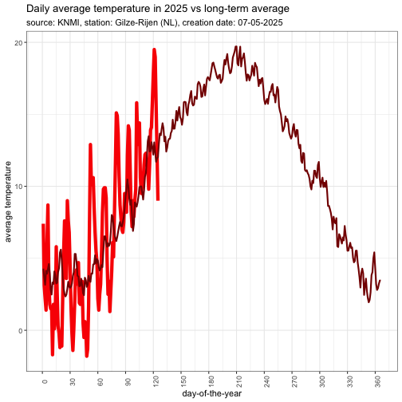

```r
data(knmi_langJarigGem)

knmi.langJarigGem <-
  knmi.langJarigGem %>%
  filter(stationID == 350)

library(ggplot2)

p <-
  ggplot() +
  geom_line(
    data = data,
    aes(x = doy, y = gemTemp),
    color = "#FA0000", show.legend = FALSE, size = 2
  ) +
  geom_line(
    data = knmi.langJarigGem,
    aes(x = doy, y = gemTemp),
    color = "#850000", show.legend = FALSE, size = 1
  ) +
  scale_x_continuous(breaks = round(seq(0, 400, by = 30), 1)) +
  scale_y_continuous(breaks = round(seq(0, 40, by = 10), 1)) +
  theme_bw() +
  theme(axis.text.x = element_text(angle = 90)) +
  labs(x = "day-of-the-year", y = "average temperature") +
  ggtitle(
    label = paste("Daily average temperature in", current_year, "vs long-term average"),
    subtitle = paste("source: KNMI, station: Gilze-Rijen (NL), creation date:",
      format(Sys.Date(),
        format = "%d-%m-%Y"
      ),
      sep = " "
    )
  )

print(p)
```

## KNMI weather forecast

The KNMI provides a [six-day weather forecast](http://www.knmi.nl/nederland-nu/weer/verwachtingen) on it’s website. Unfortunately, it’s only available for the city of ‘De Bilt’, which is located at the centre of The Netherlands.

Let’s add the forecast to the previous plot.

```r
# get the six-day weather forecast.
forecast <-
  get_6day_weather_forecast()

glimpse(forecast)
```

```
## Rows: 6
## Columns: 22
## $ STN          <dbl> 260, 260, 260, 260, 260, 260
## $ station      <chr> "De Bilt", "De Bilt", "De Bilt", "De Bilt", "De Bilt", "D…
## $ YYYYMMDD     <chr> "20250507", "20250508", "20250509", "20250510", "20250511…
## $ date         <date> 2025-05-07, 2025-05-08, 2025-05-09, 2025-05-10, 2025-05-1…
## $ TX           <dbl> 16, 19, 19, 21, 23, 23
## $ SD_maxTemp   <dbl> 0, 0, 0, 0, 0, 0
## $ TN           <dbl> 3, 5, 6, 7, 9, 10
## $ SD_minTemp   <dbl> 0, 0, 0, 0, 0, 0
## $ TG           <dbl> 9.5, 12.0, 12.5, 14.0, 16.0, 16.5
## $ SD_gemTemp   <dbl> 0, 0, 0, 0, 0, 0
## $ RH           <dbl> 0, 0, 0, 0, 0, 0
## $ SD_neerslag  <dbl> 0, 0, 0, 0, 0, 0
## $ neerslagKans <dbl> 10, 10, 0, 0, 0, 10
## $ SP           <dbl> 50, 60, 70, 80, 80, 80
## $ windkracht   <dbl> 3, 3, 3, 2, 3, 2
## $ minWind      <dbl> 3.4, 3.4, 3.4, 1.6, 3.4, 1.6
## $ maxWind      <dbl> 5.4, 5.4, 5.4, 3.3, 5.4, 3.3
## $ doy          <dbl> 127, 128, 129, 130, 131, 132
## $ year         <dbl> 2025, 2025, 2025, 2025, 2025, 2025
## $ month        <dbl> 5, 5, 5, 5, 5, 5
## $ week         <dbl> 19, 19, 19, 19, 19, 19
## $ day          <dbl> 4, 5, 6, 7, 1, 2
```

As can be seen, this dataset contains lower- and upper-bounds for some variables, indicating the uncertainty in the forecasted values.

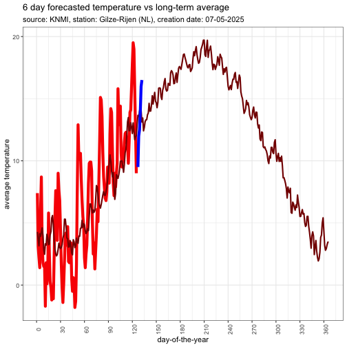

```r
forecast <-
  forecast %>%
  rename_KNMI_column_names() # 260 is the measurement station at De Bilt

# pretend that the forecast for De Bilt is also valid for Gilze-Rijen:
print(p +
  geom_line(
    data = forecast,
    aes(
      x = doy,
      y = gemTemp
    ),
    color = "#0000FF", show.legend = FALSE, size = 2
  ) +
  ggtitle(
    label = "6 day forecasted temperature vs long-term average",
    subtitle = paste("source: KNMI, station: Gilze-Rijen (NL), creation date:",
      format(Sys.Date(),
        format = "%d-%m-%Y"
      ),
      sep = " "
    )
  ))
```

## Weerplaza 14-day weather forecast

Weerplaza provides a [fourteen-day weather forecast](https://www.weerplaza.nl/nederland/) on it’s website. This forecast is available for most major cities.

Let’s add the 14-day forecast to the previous plot.

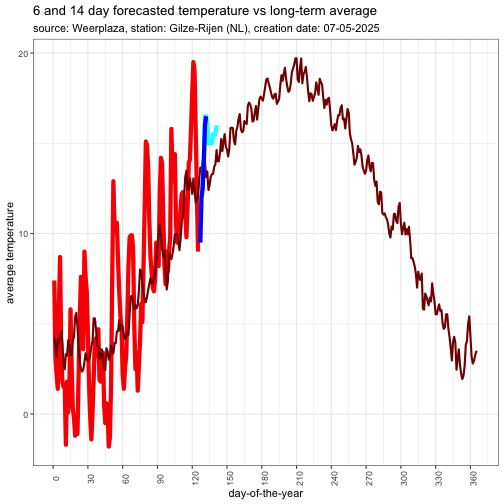

```r
# get the fourteen-day weather forecast for Gilze-Rijen.
# note that passing 'station = 350' as numeric parameter will also work.
forecast14 <-
  get_14day_weather_forecast(station = "Gilze-Rijen")

# rename the columns
forecast14 <-
  forecast14 %>%
  rename_KNMI_column_names()

print(p +
  geom_line(
    data = forecast14,
    aes(
      x = doy,
      y = gemTemp
    ),
    color = "#00FFFF", show.legend = FALSE, size = 2
  ) +
  geom_line(
    data = forecast,
    aes(
      x = doy,
      y = gemTemp
    ),
    color = "#0000FF", show.legend = FALSE, size = 2
  ) +
  ggtitle(
    label = "6 and 14 day forecasted temperature vs long-term average",
    subtitle = paste("source: Weerplaza, station: Gilze-Rijen (NL), creation date:",
      format(Sys.Date(),
        format = "%d-%m-%Y"
      ),
      sep = " "
    )
  ))
```

## Climate characteristics

The characteristics of the climate (meteogram) for a certain location can be shown with the function ‘r plot_climate_diagram’. The four characteristics mean temperature, precipitation, sun hours and wind can be selected for presentation.

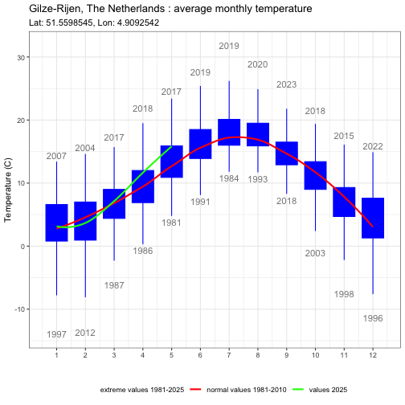

```r
# get data for the measurement station Gilze-Rijen (id=350) from January 1st, 1981 up to the most recent date provided by the KNMI (which is 'today'-1 day).
weather_data <-
  get_daily_data(
    stationID = 350,
    from = "19810101"
  ) %>%
  subset_data(variables = c("FG", "TG", "TN", "TX", "SQ", "SP", "Q", "RH", "NG")) %>%
  rename_KNMI_column_names()

plot_climate_diagram(
  data = weather_data,
  column = "gemTemp",
  startYear = 1981,
  endYear = 2010,
  currentYear = current_year
)
```

And the same for the precipitation, sun hours and wind:

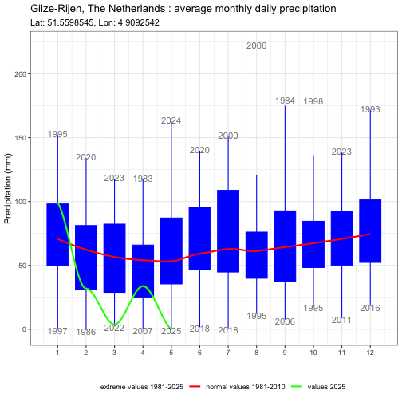

```r
plot_climate_diagram(
  data = weather_data,
  column = "dagTotaalNeerslag",
  currentYear = current_year
)
```

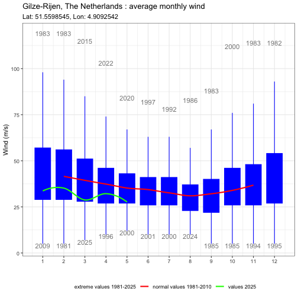

```r
plot_climate_diagram(
  data = weather_data,
  column = "gemWind",
  currentYear = current_year
)
```

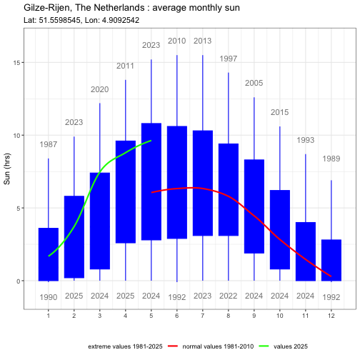

```r
plot_climate_diagram(
  data = weather_data,
  column = "zon",
  currentYear = current_year
)
```

## Feedback

Feedback on this package, or this vignette, can be provided via [github](https://github.com/BvHest/KNMIr) or by e-mail!